# Exploratory Data Analysis

Soren Gran

2024-02-26

## Dataset

Number of observations in 2020: 27,805

Number of observations in 2021: 28,336

Number of observations in full dataset: 19,532

Number of observations in full dataset who completed DCS in 2020 and 2021: 846

Number of observations in full dataset who completed SDOH in 2021: 13,023

Number of observation in full dataset who completed DCS in 2020 and 2021 and SDOH in 2021: 832

Our universe of observations (i.e. respondents who completed the DCS in both 2020 and 2021, as well as the SDOH supplement in 2021), when weighted, represents 13,489,118 non-institutionalized adults with diabetes in the U.S. in 2021.

This sample represents up 70.58% of the 19,110,902 non-institutionalized adults with diabetes in the U.S. in 2021.

# SDOH vs Outcome Variables

## DIACONF (2021)

DIACONF label: Respondent’s confidence in treating their diabetes. Administered in 2021 DCS.

Description: For all persons given the Diabetes Care Survey (DCS) and have been told they have diabetes, DIACONF indicates how confident the respondent is in their ability to care for their diabetes.

Scale: 0 = “NIU”, 1 = “Not confident at all”, 2 = “Somewhat confident”, 3 = “Confident”, 4 = “Very confident”, 7 = “Unknown-refused”, 8 = “Unknown-not ascertained”, 9 = “Unknown-don’t know”

```
## # A tibble: 5 × 6
##   DIACONF_text.y    count weighted_count in_universe_rate average_age median_age
##   <chr>             <int>          <dbl> <chr>                  <dbl>      <dbl>
## 1 Not confident at…    15        214046. 1.59 %                  64.9         68
## 2 Somewhat confide…   159       2686841. 19.92 %                 64.2         66
## 3 Confident           304       4743723. 35.17 %                 66.4         67
## 4 Very confident      321       5402920. 40.05 %                 65.1         67
## 5 Unknown              33        441588. 3.27 %                  64.1         66
```

### DIACONF (2021) vs AGE (2021)

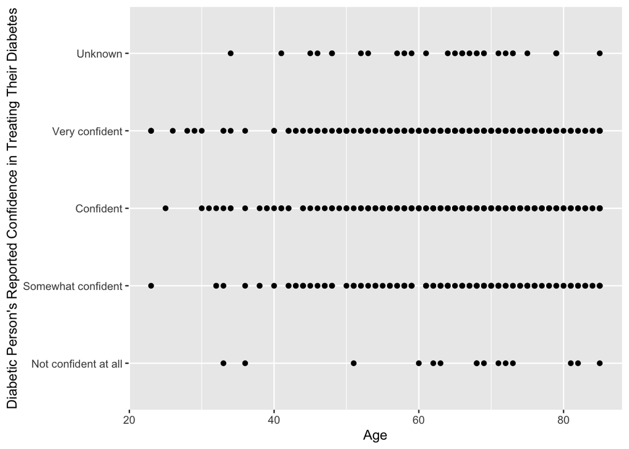

### TRANSBAR (2021) vs DIACONF (2021)

TRANSBAR label: Lack of transportation keeps person from medical appointments, meetings, work, or activities of daily living, past 12 months. Administered in 2021 SDOH supplement.

Description: TRANSBAR indicates whether, during the last 12 months, a lack of reliable transportation kept them from medical appointments, meetings, work, or from getting things needed for daily living.

#### DIACONF = Not confident at all (n = 15)

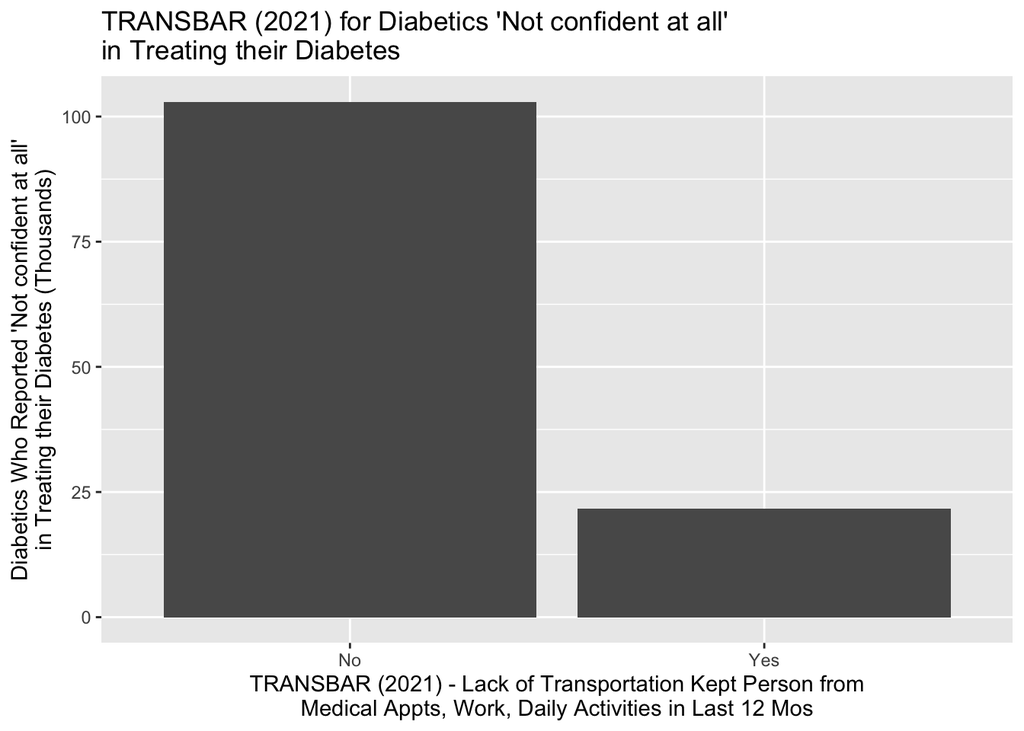

#### DIACONF = Somewhat confident (n = 159)

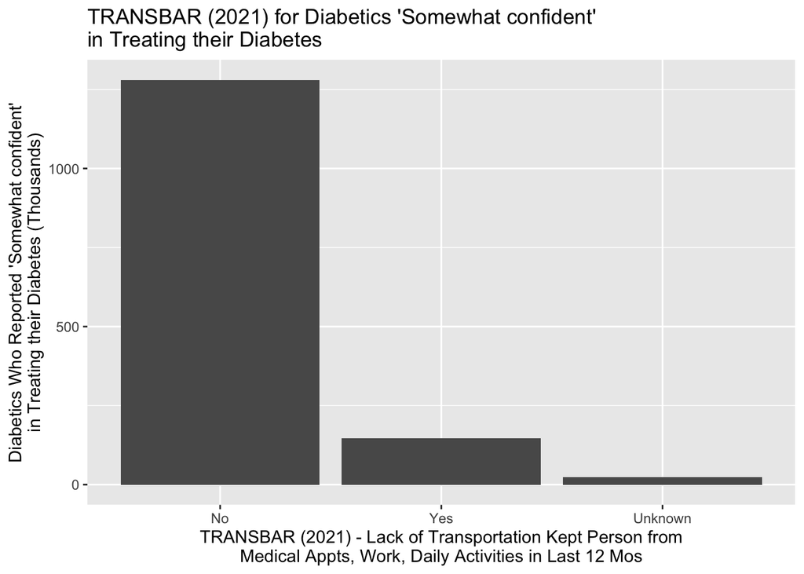

#### DIACONF = Confident (n = 304)

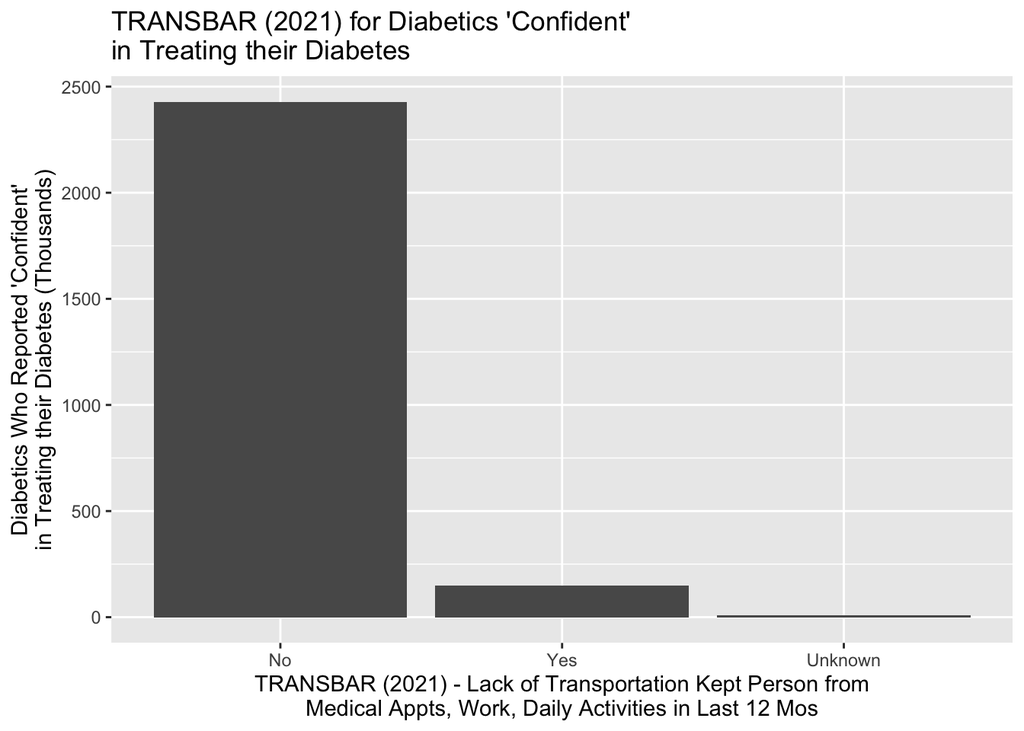

#### DIACONF = Very Confident (n = 321)

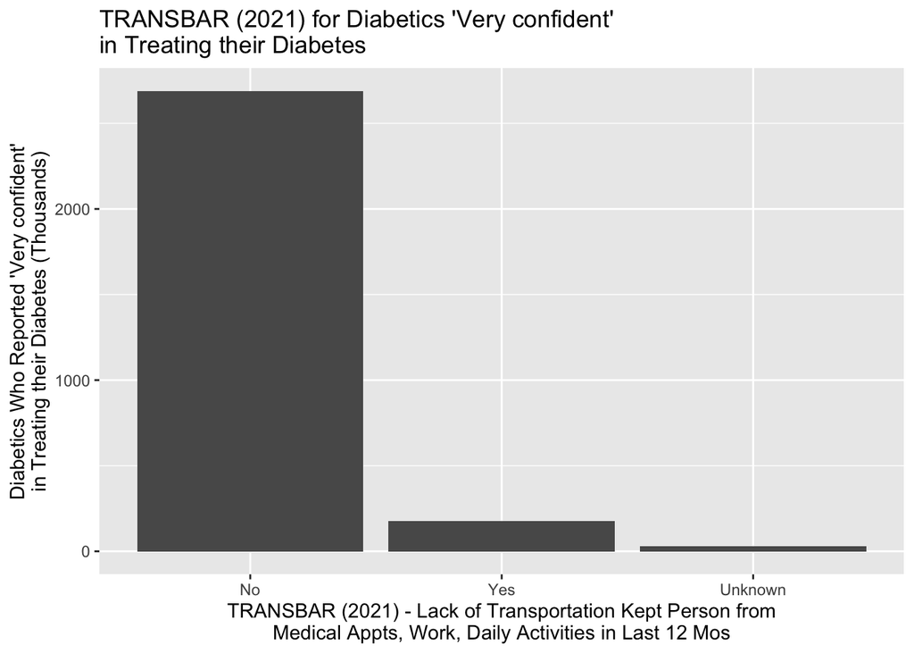

### TRANSBAR (2021) vs DIACONF (2021) vs AGE (2021)

#### DIACONF = Not confident at all (n = 15)

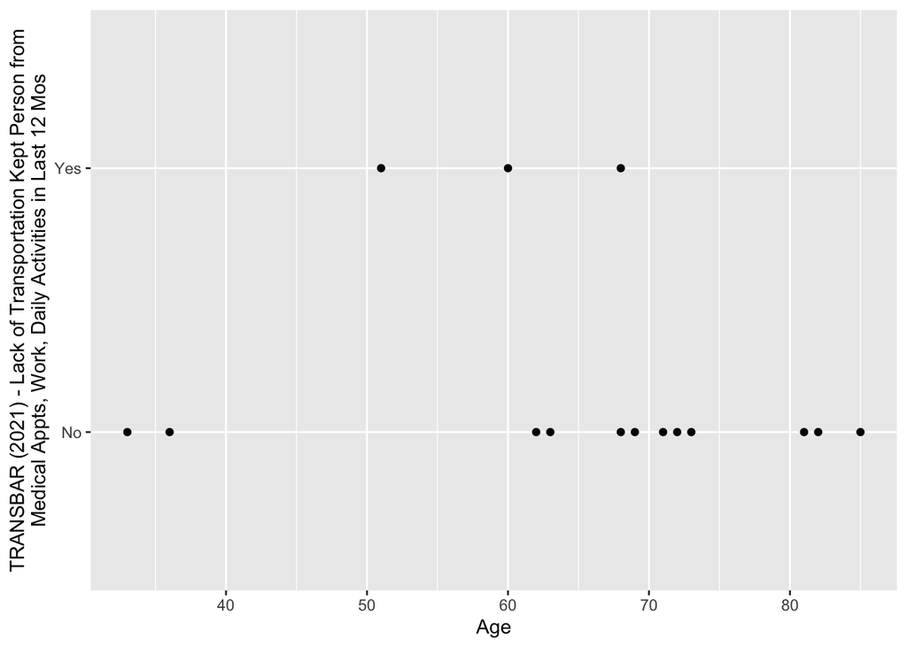

#### DIACONF = Somewhat confident (n = 159)

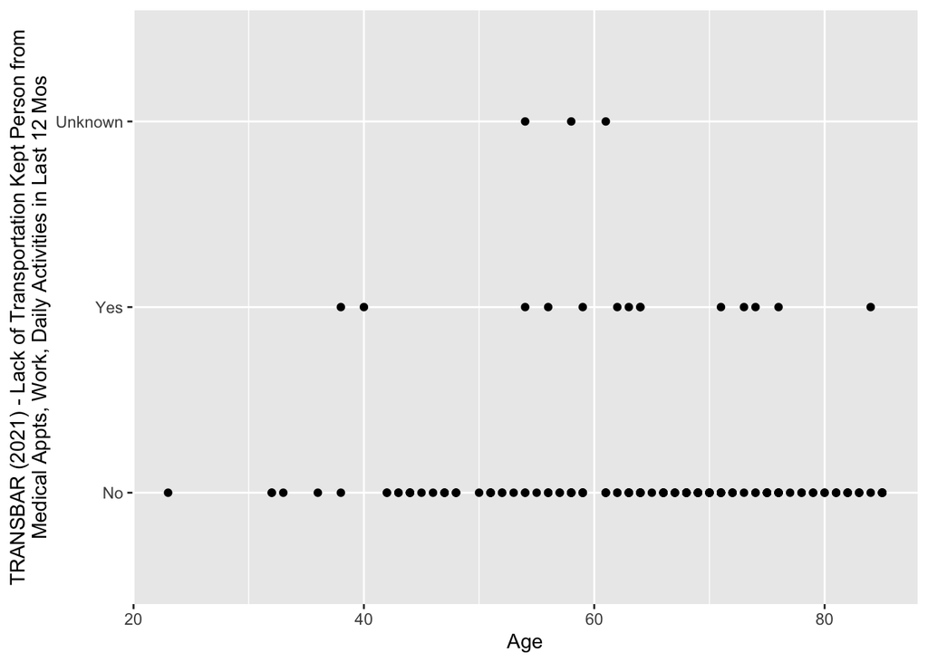

#### DIACONF = Confident (n = 304)

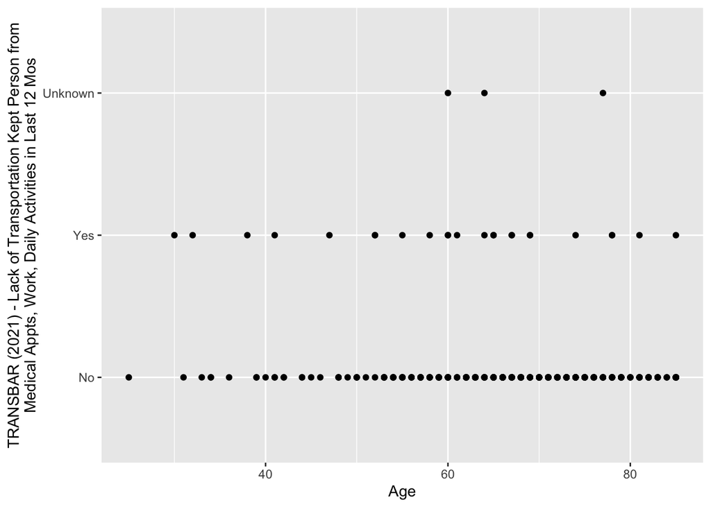

#### DIACONF = Very Confident (n = 321)

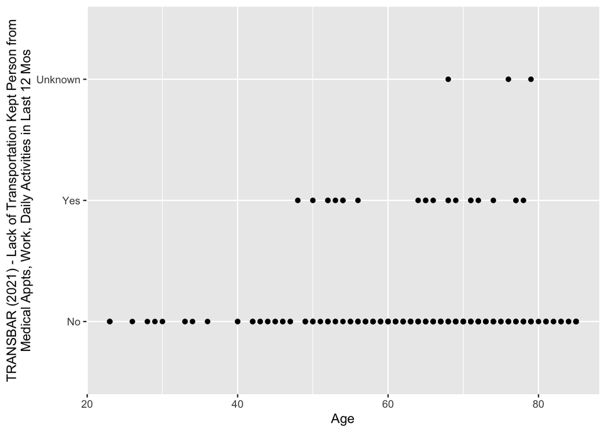

### RATEMEDCARE (2021) vs DIACONF (2021)

RATEMEDCARE label: Rate neighborhood availability of places to get medical care. Administered in 2021 SDOH supplement.

Description: RATEMEDCARE indicates the respondent’s rating of the availability of places to get medical care in their neighborhood.  
Scale: Ratings on a scale of 1 to 9 (“Poor”, “Fair or poor”, “Fair”, “Good or fair”, “Good”, “Very good or good”, “Very good”, “Excellent or very good”, “Excellent”)

#### DIACONF = Not confident at all (n = 15)

[figure not shown]

#### DIACONF = Somewhat confident (n = 159)

[figure not shown]

#### DIACONF = Confident (n = 304)

[figure not shown]

#### DIACONF = Very Confident (n = 321)

[figure not shown]

### RATEMEDCARE (2021) vs DIACONF (2021) vs AGE (2021)

#### DIACONF = Not confident at all (n = 15)

[figure not shown]

#### DIACONF = Somewhat confident (n = 159)

[figure not shown]

#### DIACONF = Confident (n = 304)

[figure not shown]

#### DIACONF = Very Confident (n = 321)

[figure not shown]

## DIACLASS (2021)

DIACLASS label: Ever took class in diabetes management. Administered in 2021 DCS.

Description: For all persons given the Diabetes Care Survey (DCS), have been told they have diabetes, and have learned how to take care of their diabetes in the last 12 months, DIACLASS indicates whether the respondent has learned how to treat their diabetes by taking a group class.

Scale: 0 = “NIU”, 1 = “No”, 2 = “Yes”, 7 = “Unknown-refused”, 8 = “Unknown-not ascertained”, 9 = “Unknown-don’t know”

```
## # A tibble: 3 × 6
##   DIACLASS_text.y count weighted_count in_universe_rate average_age median_age
##   <chr>           <int>          <dbl> <chr>                  <dbl>      <dbl>
## 1 No                566       8813719. 65.34 %                 65.7         67
## 2 Yes                45        878788. 6.51 %                  64.8         69
## 3 <NA>              221       3796610. 28.15 %                 64.5         67
```

### DIACLASS (2021) vs AGE (2021)

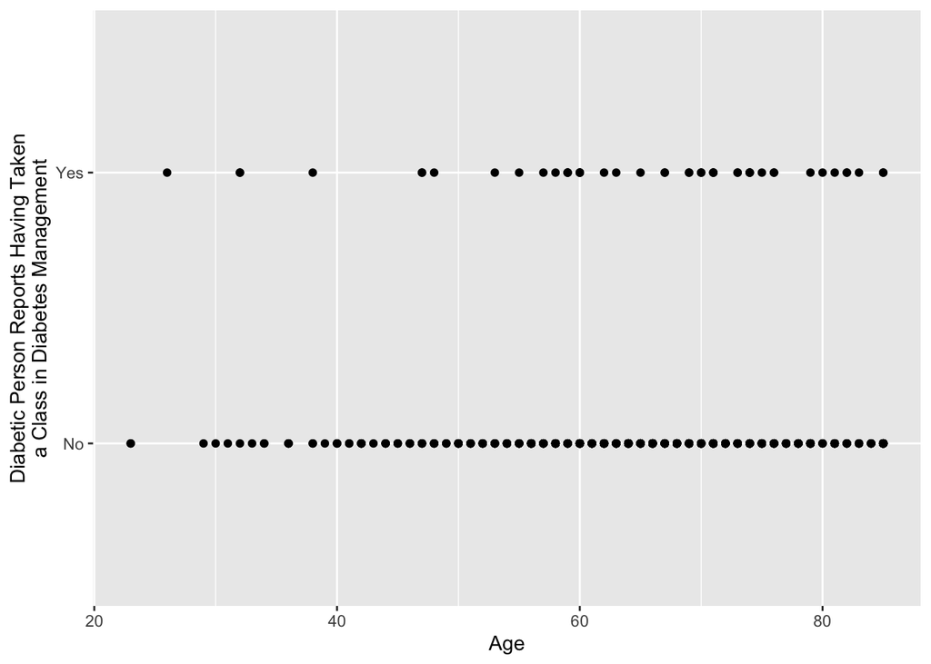

### HARDPAYBASIC (2021) vs DIACLASS (2021)

HARDPAYBASIC label: How hard to pay for basics like food, housing, medical care, and heating. Administered in 2021 SDOH supplement.

Description: HARDPAYBASIC indicates how hard it is for the respondent to pay for basics such as food, housing, medical care, and heating.

Scale: Ratings on a scale of 1 to 5 (“Not at all hard”, “Somewhat or not at all hard”, “Somewhat hard”, “Very or somewhat hard”, “Very hard”)

#### DIACLASS = No (n = 566)

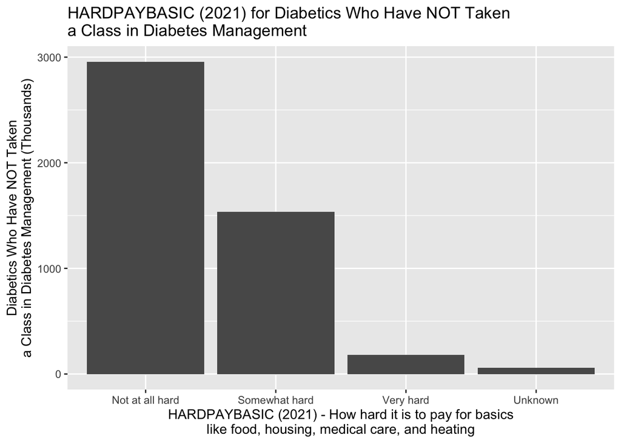

#### DIACLASS = Yes (n = 45)

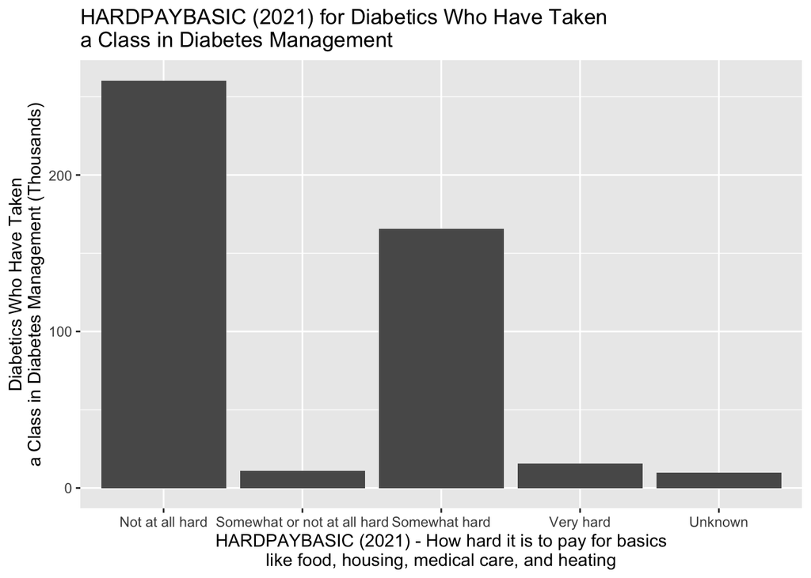

### HARDPAYBASIC (2021) vs DIACLASS (2021) vs AGE (2021)

#### DIACLASS = No (n = 566)

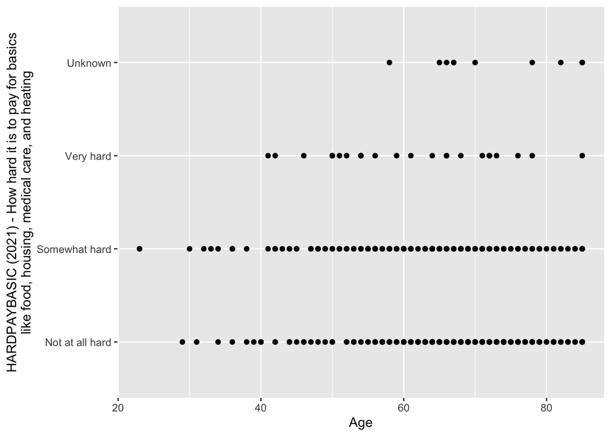

#### DIACLASS = Yes (n = 45)

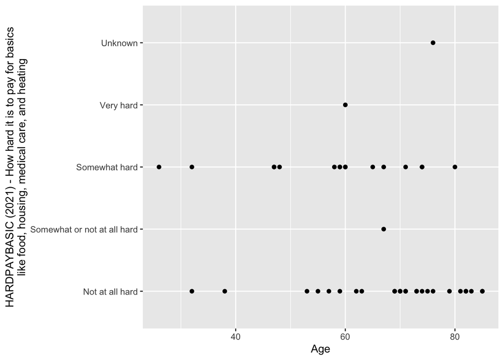

## DIETFOLLOW (2021)

DIETFOLLOW label: Now follow special diet. Administered in 2021 DCS.

Description: DIETFOLLOW indicates whether a respondent is treating their diabetes by modifying their diet.

Scale: 0 = “NIU”, 10 = “No”, 20 = “Yes”, 90 = “Unknown”, 96 = “Unknown-don’t know/refused”, 97 = “Unknown-refused”, 98 = “Unknown-not ascertained”, 99 = “Unknown-don’t know”

```
## # A tibble: 3 × 6
##   DIETFOLLOW_text.y count weighted_count in_universe_rate average_age median_age
##   <chr>             <int>          <dbl> <chr>                  <dbl>      <dbl>
## 1 No                  168       2644562. 19.61 %                 65.0         68
## 2 Yes                 657      10765935. 79.81 %                 65.5         67
## 3 Unknown               7         78622. 0.58 %                  61.1         62
```

### DIETFOLLOW (2021) vs AGE (2021)

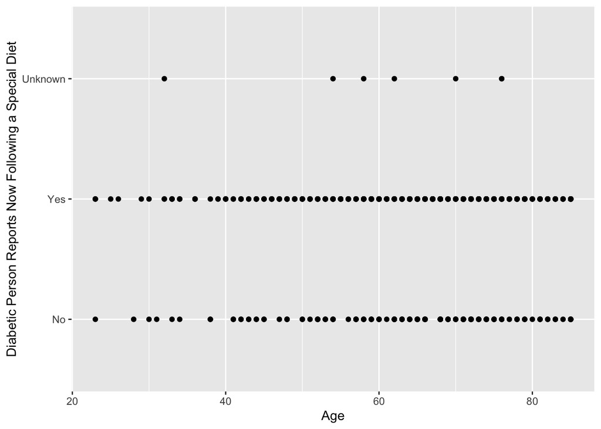

### RATEHLTHFD (2021) vs DIETFOLLOW (2021)

RATEHLTHFD label: Rate neighborhood availability of places to buy healthy food. Administered in 2021 SDOH supplement.

Description: RATEHLTHFD indicates the respondent’s rating of the availability of places to buy healthy food in their neighborhood.

Scale: Ratings on a scale of 1 to 9 (“Poor”, “Fair or poor”, “Fair”, “Good or fair”, “Good”, “Very good or good”, “Very good”, “Excellent or very good”, “Excellent”)

#### DIETFOLLOW = No (n = 168)

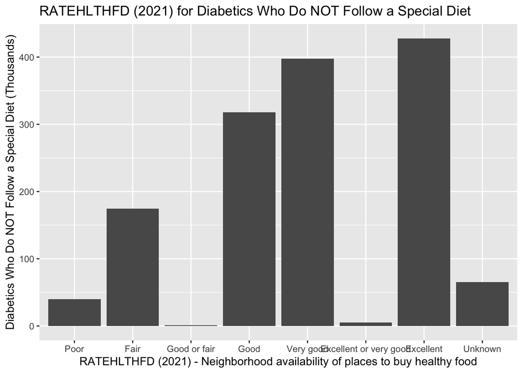

#### DIETFOLLOW = Yes (n = 657)

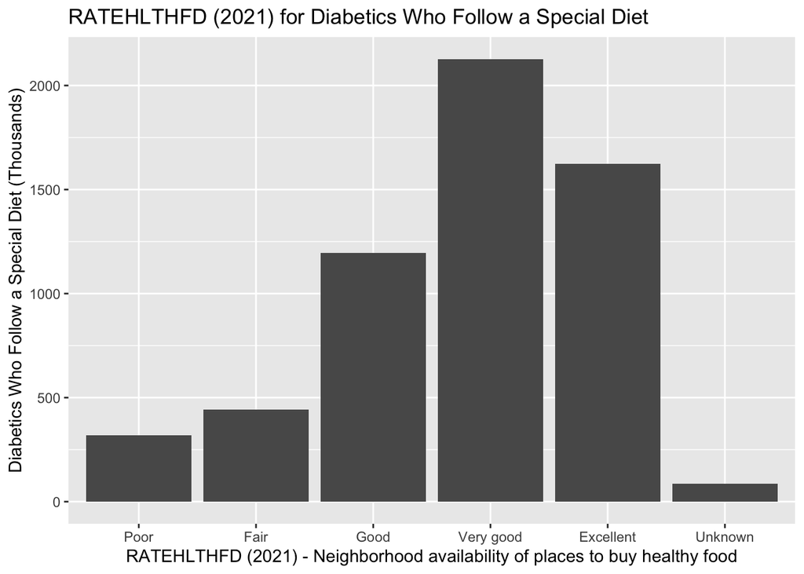

### RATEHLTHFD (2021) vs DIETFOLLOW (2021) vs AGE (2021)

#### DIETFOLLOW = No (n = 168)

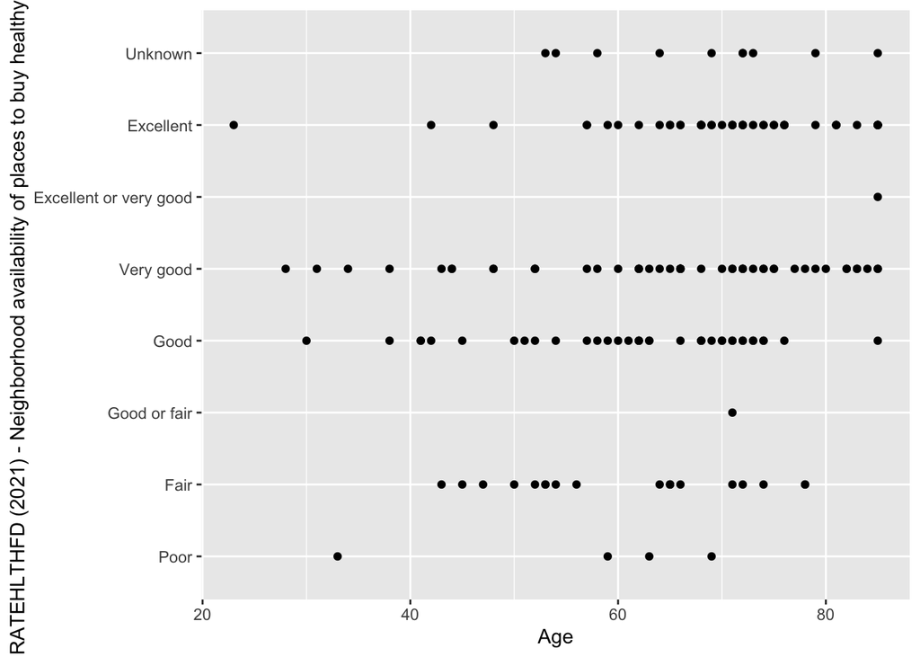

#### DIETFOLLOW = Yes (n = 657)

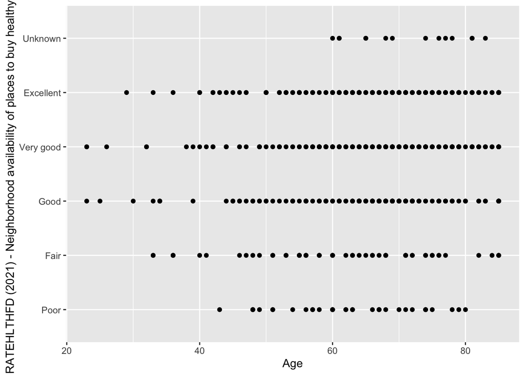